# Fundamentos de los métodos estadísticos

En el control de calidad, se infiere la población de muestras utilizando métodos estadísticos. Es necesario comprender los fundamentos de los métodos estadísticos para aplicar técnicas como pruebas de hipótesis, estimaciones, diseño de experimentos y análisis de regresión.

- Explicación de las propiedades del valor esperado, la varianza y la covarianza.
- Distribución normal, distribución binomial, distribución de Poisson y la demostración de sus probabilidades.
- Comprensión de la distribución normal, la distribución t, la distribución de la varianza de la suma de cuadrados (distribución chi-cuadrado), la distribución del cociente de varianzas (distribución F) y la explicación del cálculo de sus probabilidades.
- Explicación de la ley de los grandes números y el teorema del límite central.

[Audio_1](https://drive.google.com/file/d/1icpTE7wg_BzHhRyJxhBrO8oVIqTs6dd1/view?usp=drive_link)

```python
import os

try:
  os.chdir('../Python/QCKentei2')
except:
  pass

path = os.getcwd()
```

```python
import numpy as np
import matplotlib.pyplot as plt
import pandas as pd
```

## 03-01 Valor esperado y varianza

期待値と分散

### 1. ¿Cuál es el **valor esperado**?

期待値とは

Una variable aleatoria discreta cuya característica de calidad puede expresarse en valores contables (de conteo).

$ E(X) = \sum x_i Pr(X = x_i) $

Una variable aleatoria continua cuya característica de calidad puede expresarse en valores medibles (cuantitativos).

$ E(X) = \int x f(x) dx $

### 2. Propiedades del valor esperado

期待値の性質

1. $ E(aX) = aE(X) $
2. $ E(aX+C) = aE(X) + C $
3. $ E(a_1 X_1 + a_2X_2 + ... + a_n X_n) = a_1E(X_1) + a_2 E(X_2) + ... + a_n E(X_n) $

   $ E(X_1 + X_2) = E(X_1) + E(X_2) $

   $ E(X_1 - X_2) = E(X_1) - E(X_2) $

[Audio_2](https://drive.google.com/file/d/1rRRM3V51iSB4KRL_HKpb1AhIax6jzsEo/view?usp=drive_link)

## 3.1

X, X1, X2 が確率変数であるとき、以下を求めよ。

Sean X, X1, X2 variables aleatorias. Calcule lo siguiente.

1. $ E(2X+5) $
2. $ E(2X1 + 3X2) $
1. $ E(2X+5) = 2E(X) + 5 $
2. $ E(2X1 + 3X2) = 2E(X1) + 3E(X2) $

### 3. ¿Qué son la varianza y la covarianza?

分散・共分散とは

Una variable aleatoria discreta cuya característica de calidad se expresa en valores contables.

$ V(X) = \sum (x_i - \mu)^2 Pr(X=x_i) $

Una variable aleatoria continua cuya característica se expresa en valores medibles.

$ V(X) = \int (x-\mu)^2 f(x) dx $

### 4. Propiedades de la varianza la covarianza

分散・共分散の性質

1. $ V(aX) = a^2 V(X) $
2. V(aX + C) = a^2 V(X) $
3. X_1, X_2, ... X_n son independientes entre si.

   $ V(a_1 X_1 + a_2X_2 + ... + a_nX_n) = a_1^2 V(X_1) + a_2^2 V(X_2) + ... + a_n^2 V(X_n) $

   $ V(X_1 + X_2) = V(X_1) + V(X_2) $

   $ V(X_1 - V_2) = V(X_1) + V(X_2) $
- **Adición de varianzas**（分散の加法性）

[Audio_3](https://drive.google.com/file/d/1jSU9O5mqyArcMpWT0WXl20SoHGAHagFS/view?usp=drive_link)

## 3.2

X, X1, X2 が確率変数であるとき、以下を求めよ。

Sean X, X1, X2 variables aleatorias. Calcule lo siguiente.

1. $ V(2X+5) $
2. $ V(2X1+3X2) $
3. $ X1 \sim N(20, 3^2) $ y $ X2 \sim N(30, 3^2) $

   $ E(4X1 + 5X2) $

   $ V(4X1 + 5X2) $
4. $ X1 \sim N(20, 3^2) $, $ X2 \sim N(30, 3^2) $ y $ Cov(X1, X2) = 0.5 $

   $ E(4X1 + 5X2) $

   $ V(4X1 + 5X2) $
1. $ V(2X+5) = 2^2 V(X) + 0 = 4V(X) $
2. $ V(2X1+3X2) = 2^2 V(X1) + 3^2 V(X2) = 4V(X1)+9V(X2) $
3. $ X1 \sim N(20, 3^2) $ y $ X2 \sim N(30, 3^2) $

   $ E(4X1 + 5X2) = 4E(X1) + 5E(X2) = 4 \times 20 + 5 \times 30 = 230 $

   $ V(4X1 + 5X2) = 4^2 V(X1) + 5^2 V(X2) = 16 \times 3^2 + 25 \times 3^2 = 369 $
4. $ X1 \sim N(20, 3^2) $, $ X2 \sim N(30, 3^2) $ y $ Cov(X1, X2) = 0.5 $

   $ E(4X1 + 5X2) = 4 E(X1) + 5 E(X2) = 4 \times 20 = 5 \times 30 = 230 $

   $ V(4X1 + 5X2) = 4^2 V(X1) + 5^2 V(X2) + 2 \times 4 \times 5 Cov(X1, X2) $

   $ = 16 \times 3^2 + 25 \times 3^2 + 40 \times 40 \times 0.5 = 389 $

## 3.3

２種類の部品を別々に製造し、これらを組み合わせて製品を作る工程がある。図３．２に示す製品についてMの寸法の期待値E(M)と分散V(M)を求めよ。

1. 部品Aの長さXは正規分布 $ N(30, 2^2) $、部品Bの長さYは正規分布 $ N(10, 1^2) $ に従い、互いに独立である場合。
2. XとYが互いに独立ではなく、$ Cov(X, Y) = 0.5 $ の場合。

Se fabrican dos tipos de piezas por separado y luego se ensamblan para formar un producto. Para el producto mostrado en la Figura 3.2, calcule el valor esperado E(M) y la varianza V(M) de la dimensión M.

1. Cuando la longitud de la pieza A, X, sigue una distribución normal $ N(30, 2^2) $, y la longitud de la pieza B, Y, sigue una distribución normal $ N(10, 1^2) $, y ambas son independientes entre sí.
2. Cuando X y Y no son independientes y $ Cov(X, Y) = 0.5 $

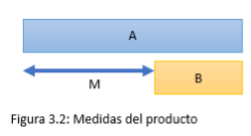

```python
from IPython.display import display
from PIL import Image

img = Image.open('./Graph2/Fig3-2.png')
display(img)
```

```python
# Media y varianza de X e Y
mu_X = 30
var_X = 2**2  # = 4

mu_Y = 10
var_Y = 1**2  # = 1

# Caso 1: X e Y son independientes
# → Cov(X, Y) = 0
cov_XY_indep = 0

E_M_indep = mu_X - mu_Y
V_M_indep = var_X + var_Y - 2 * cov_XY_indep

# Caso 2: X e Y no son independientes, Cov(X,Y) 0.5
cov_XY_corr = 0.5

E_M_corr = mu_X - mu_Y
V_M_corr = var_X + var_Y - 2 * cov_XY_corr

# 結果を表示
print("Caso 1: X e Y son independientes")
print(f"Valor esperado E(M) = {E_M_indep}")
print(f"Varianza V(M)  = {V_M_indep}")

print("\nCaoso 2: X e Y no son independientes、Cov(X,Y)=0.5:")
print(f"Valor esperado E(M) = {E_M_corr}")
print(f"Varianza V(M)  = {V_M_corr}")
```

```
Caso 1: X e Y son independientes
Valor esperado E(M) = 20
Varianza V(M)  = 5

Caoso 2: X e Y no son independientes、Cov(X,Y)=0.5:
Valor esperado E(M) = 20
Varianza V(M)  = 4.0
```

## 03-02 Distribución normal

正規分布

### 1. ¿Qué es la distribución normal?

正規分布とは

En cuanto a las variables cuantitativas, la distribución normal es la más importante y común. La distribución normal presenta una forma de campana simétrica.

$ f(x) = \frac{1}{\sqrt{2 \ pi \sigma}} exp\bigl(-\frac{(x -\mu)^2}{2 \sigma^2} \bigr)$

$ E(X) = \mu $

$ V(X) = \sigma^2 $

### 2. Probabilidad de la distribución normal

正規分布の確率

- Estandarización（標準化）
  - $ u = \frac{x - \mu}{\sigma} $
  - $ N(\mu, \sigma^2) $ => $ N(0,1^2) $
- Distribución normal estándar（標準正規分布）

[Audio_4](https://drive.google.com/file/d/1YHEXsMRnyVs_bJnM-po7M8HHC01H9tON/view?usp=drive_link)

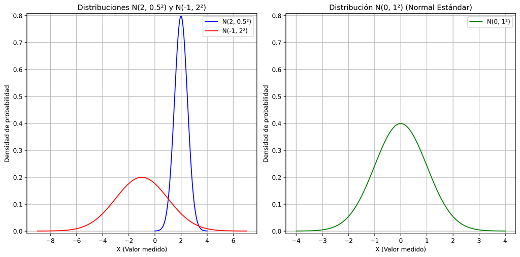

```python
from PIL import Image
img = Image.open('./Graph2/norm3.png')
display(img)
```

## 3.4

正規分布 KpからP、PからKpを求めよ。

En una distribución normal, calcula P a partir del Kp y Kp a partir de P.

1. $ P_r(u \ge 1.96) $
2. $ P_r(u \ge 3.00) $
3. $ P_r(u \ge 1.05) $
4. $ P_r(u \leq -2.09) $
5. $ P_r(-2.09 \leq u \leq -1.05) $
6. $ P = 0.05 $
7. $ P = 0.10 $

```python
import scipy.stats as stats

# 1. Pr(u ≥ 1.96)
pr_u_1_96 = 1 - stats.norm.cdf(1.96)
print(f"Pr(u ≥ 1.96) = {pr_u_1_96:.4f}")

# 2. Pr(u ≥ 3.00)
pr_u_3_00 = 1 - stats.norm.cdf(3.00)
print(f"Pr(u ≥ 3.00) = {pr_u_3_00:.4f}")

# 3. Pr(u ≥ 1.05)
pr_u_1_05 = 1 - stats.norm.cdf(1.05)
print(f"Pr(u ≥ 1.05) = {pr_u_1_05:.4f}")

# 4. Pr(u ≤ -2.09)
pr_u_leq_neg_2_09 = stats.norm.cdf(-2.09)
print(f"Pr(u ≤ -2.09) = {pr_u_leq_neg_2_09:.4f}")

# 5. Pr(-2.09 ≤ u ≤ -1.05)
pr_u_range = 1- stats.norm.cdf(-1.05) - stats.norm.cdf(-2.09)
print(f"Pr(-2.09 ≤ u ≤ -1.05) = {pr_u_range:.4f}")

# 6. P = 0.05 and P = 0.10 の場合のKp
k_p_05 = stats.norm.ppf(0.05)  # P = 0.05 に対応する Kp
k_p_10 = stats.norm.ppf(0.10)  # P = 0.10 に対応する Kp
print(f"Kp for P = 0.05: {k_p_05:.3f}")
print(f"Kp for P = 0.10: {k_p_10:.3f}")
```

[output not shown]

## 03-03 Distribución binomial

二項分布

### 1. Distribución binomial

二項分布

Las tasas de productos defectuosos y el número de productos defectuosos, que son valores discretos (o datos de conteo), siguen una **distribución binomial**. Cuando se extraen aleatoriamente $ n $ muestras de un proceso con una proporción de productos defectuosos de la población $ P $, la probabilidad $ P_x $ de que haya $ x $ productos defectuosos en la muestra es:

$ P_r (X = x ) = {}_n C_x P^x (1-P)^{n-x} = \frac{n!}{x!(n-x)!} P^x (1-P)^{n-x}$

La media (valor esperado) y la varianza de la distribución binomial son: 二項分布の平均と分散は

$ E(X) = np $

$ V(X) = np(1-P) $

[Audio_5](https://drive.google.com/file/d/1S_ZXw85iQSCMw0iq_X7SLLxtPk9yfZ3Y/view?usp=drive_link)

La distribución binorial para varias proporciones de no conformes de la población (P)

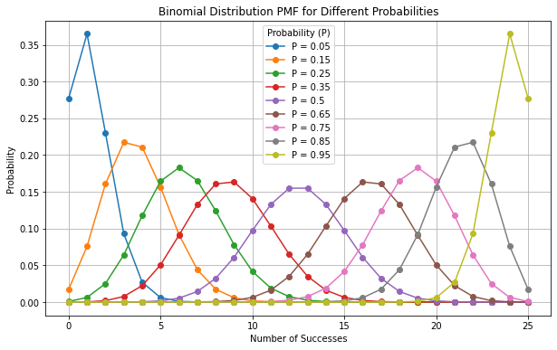

```python
from scipy.stats import binom

# 与えられた確率Pとサンプルサイズn
P = [0.05, 0.15, 0.25, 0.35, 0.50, 0.65, 0.75, 0.85, 0.95]
n = 25

# x軸の値（成功回数の範囲）
x = np.arange(0, n+1)

# プロットの準備
plt.figure(figsize=(10, 6))

# 各確率PについてPMFを計算し、グラフを描画
for p in P:
    pmf = binom.pmf(x, n, p)
    plt.plot(x, pmf, label=f'P = {p}', marker='o')

# グラフのラベル設定
plt.title('Binomial Distribution PMF for Different Probabilities')
plt.xlabel('Number of Successes')
plt.ylabel('Probability')
plt.legend(title="Probability (P)")

# グラフの表示
plt.grid(True)
plt.show()
```

### 2. Probabilidad de la distribución binomial

２項分布の確率

Calcular la probabilidad de que hay 3 productos defectuosos en una muestra de 20, tomaba de un proceso con una tasa de productos defectuosos (proporción de no conformes) $ P = 0.10 $

[Audio_6](https://drive.google.com/file/d/1cCwtrN7wQ64vq2k21KCJfiQBEsxih1x5/view?usp=drive_link)

```python
from scipy.stats import binom

# Parámetro
n = 20      # Tamaño de muestra
p = 0.10    # Tasa de productos defectuosos
k = 3       # Número de productos defectuosos

# Calcular la probabilidad con la distribución binomial
probability = binom.pmf(k, n, p)

print(f"Probabilidad de que se incluyen 3 productos defectuosos: {probability:.5f}")
```

```
Probabilidad de que se incluyen 3 productos defectuosos: 0.19012
```

## 3.5

不適合品率 $ P = 0.20 $ の工程から、サンプルを２０個抜き取ったとき、サンプル中の不適合品率が２個以下である確率を求めよ。

En un proceso con una tasa de productos defectuosos $ P = 0.20 $ se extraen 20 muestras. Calcule la probabilidad de que el número de productos defectuosos en la muestra sea 2 o menos.

```
La probabilidad de que el número de artículos
defectuosos en la muestra sea 2 o menos es: 0.2061
```

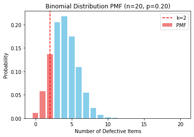

```python
from scipy.stats import binom

# パラメータの設定
n = 20  # サンプル数
p = 0.20  # 不適合品率
k = np.arange(0, n+1)  # 不適合品数

# 二項分布の確率質量関数 (PMF)
pmf = binom.pmf(k, n, p)

# サンプル中の不適合品が2個以下である確率
probability = binom.cdf(2, n, p)


print("La probabilidad de que el número de artículos ")
print(f"defectuosos en la muestra sea 2 o menos es: {probability:.4f}\n")

colors = ['skyblue' if i > 2 else 'lightcoral' for i in k]  # 2以下のバーに別の色を付ける

plt.bar(k, pmf, color=colors, label='PMF')
plt.axvline(x=2, color='red', linestyle='--', label='k=2')
plt.title('Binomial Distribution PMF (n=20, p=0.20)')
plt.xlabel('Number of Defective Items')
plt.ylabel('Probability')
plt.legend()
plt.show()
```

## 03-04 Distribución de Poisson

ポアソン分布

### 1. Distribución de Poisson

ポアソン分布

La **distribución de Poisson** es la distribución que se obtiene cuando, en una distribución binomial, se mantiene el producto $ nP = \lambda $ constante y el tamaño de la muestra $ n $ tiende a infinito. El número de defectos encontrados en un producto de tamaño constante o el número de accidentes por día, por ejemplo, siguen una distribución de Poisson.

$ P(X=x) = exp^{-λ} \frac{\lambda x}{x!}$

La **media (valor esperado)** y la **varianza** de la distribución de Poisson son: ポアソン分布の平均と分散は

$ E(x) = \lambda $

$ V(x) = \lambda $

En la distribución binomial, si $ P \leq 0.1 $, se considera que, a efectos prácticos, se puede tratar como una distribución de Poisson. En este caso, la media y la probabilidad de la distribución binomial se expresan mediante las siguientes fórmulas:

$ E(X) = np $

$ V(X) = nP $

[Audio-7](https://drive.google.com/file/d/1_58M7rKlWLdO3gVEO3z-UC6YPlrRbeE_/view?usp=drive_link)

Distribuciones de Poisson para deferentes $ \lambda $

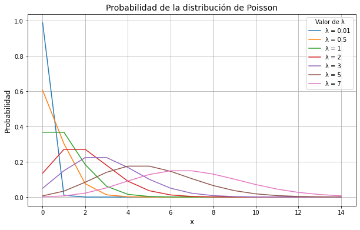

```python
from scipy.stats import poisson

# Valor λ
lambda_values = [0.01, 0.5, 1, 2, 3, 5, 7]

x = np.arange(0, 15)

plt.figure(figsize=(10, 6))

for lam in lambda_values:
    y = poisson.pmf(x, lam)  # Función de masa de probabilidad de la distribución de Poisson
    plt.plot(x, y, label=f'λ = {lam}')

# グラフの設定
plt.title('Probabilidad de la distribución de Poisson', fontsize=14)
plt.xlabel('x', fontsize=12)
plt.ylabel('Probabilidad', fontsize=12)
plt.legend(title='Valor de λ', fontsize=10)
plt.grid(True)
plt.show()
```

### 2. Probabilidad de la distribución de Poisson

ポアソン分布の確率

La probabilidad de la distribución de Poisson se calcula utilizando la siguiente fórmula:

$ Pr(X=x) = exp(-\lambda) \frac{\lambda^{\lambda}}{x!} \qquad (x = 0, 1, 2, ...; \lambda > 0 )$

[Audio_8](https://drive.google.com/file/d/1V4JFABAD3znXwNkAZnQDFz-MXa6SvaoA/view?usp=drive_link)

## 3.6

不適合数 $ \lambda = 4 $ の工程から、サンプルを１単位抜き取ったとき、サンプル中の不適合数が２個以下である確率を求めよ。

Determine la probabilidad de que el número de defectos en una muestra de una unidad extraída de un proceso con $ \lambda = 4 $ sea igual o menor a 2.

```
Probabilidad de que el número de
defectos en la muestra sea 2 o menos : 0.2381
```

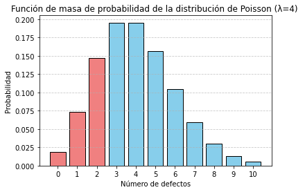

```python
from scipy.stats import poisson

# λ = 4
lambda_value = 4

#
probability = poisson.cdf(2, lambda_value)
print("Probabilidad de que el número de ")
print(f"defectos en la muestra sea 2 o menos : {probability:.4f}\n")

# Valores de la función de masa de probabilidad（PMF）の値を求めてグラフを作成
x = np.arange(0, 11)
pmf_values = poisson.pmf(x, lambda_value)

# Graph
colors = ['skyblue' if i > 2 else 'lightcoral' for i in k]  # 2以下のバーに別の色を付ける
plt.bar(x, pmf_values, color=colors, edgecolor='black')
plt.title('Función de masa de probabilidad de la distribución de Poisson (λ=4) ')
plt.xlabel('Número de defectos')
plt.ylabel('Probabilidad')
plt.xticks(x)
plt.grid(axis='y', linestyle='--', alpha=0.7)
plt.show()
```

## 03-05 Distribución de las estadísticas

統計量の分布

Las medias y varianzas de los datos obtenidos al tomar muestras de una población que sigue una distribución normal (población normal) no son valores constantes, sino que varían con cada muestra. A estas cantidades se les llama **estadísticos**（統計量）.

Si las muestras se extraen mediante muestreo aleatorio de manera probabilísticamente justa, el estadístico también sigue una distribución de probabilidad.

### 1. Distribución de la media muestral ( $ \sigma $ conocido)

サンプルの平均 $ \bar{x} $の分布（σ既知）

$ E(\bar{x}) = \mu $

$ V(\bar{x}) = \frac{1}{n} \sigma^2 $

La media muestral $ \bar{x} $ de una muestra de tamaño $ n $ extraída aleatoriamente de una población normal $ N (\mu , \sigma^2) $ sigue una distribución normal $ N(\mu, \frac{1}{n} \sigma^2 )$

[Auido_9](https://drive.google.com/file/d/1QqNbwL-Z2tZAonsAZFRAvmBfQ0MtrbY0/view?usp=drive_link)

## 3.7

1. 正規母集団 $ N(30,3^2) $ から大きさ $ n=16 $ のサンプルを抜き取ったとき、サンプルの平均 $ \bar{x} $ の分布の平均と分散 $ V(\bar{x}) $ を求めよ。また、この分布から $ n=16 $ のサンプルを抜き取った。このサンプルの平均 $ \bar{x} $ が 28 より小さくなる確率をもとめよ。
1. Sea $ N(30,3^2) $ una población normal. Cuando se extrae una muestra de tamaño $ n=16 $, calcule la media y la varianza $ V(\bar{x}) $ de la distribución de la media muestral $ \bar{x} $. Además, calcule la probabilidad de que la media muestral $ \bar{x} $ de una muestra extraída de esta distribución sea menor que 28.

```
La probabilidad de que la media muestral sea menor que 28: 0.0038
```

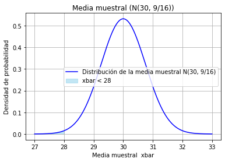

```python
from scipy.stats import norm

# Configuración de los parámetros
mu = 30  # Media de la población
sigma = 3  # Desviación estándar de la población
n = 16  # Tamaño de nuestra

# Media y varianza de la distribución de la media muestral
mean_x_bar = mu  # Media de la distribución de la media muestral
variance_x_bar = sigma**2 / n  # Varianza de la distribución de la media muestral
stddev_x_bar = np.sqrt(variance_x_bar)  # Desviación estándar de la media muestral

# Calcular la probabilidad de que la media muestral xbar se menor que 28
prob_less_than_28 = norm.cdf(28, loc=mean_x_bar, scale=stddev_x_bar)
print(f"La probabilidad de que la media muestral sea menor que 28: {prob_less_than_28:.4f}")

# Crear el gráfico de la distribución de la media muestral
x_values = np.linspace(mu - 4*stddev_x_bar, mu + 4*stddev_x_bar, 1000)
y_values = norm.pdf(x_values, loc=mean_x_bar, scale=stddev_x_bar)

plt.plot(x_values, y_values, label='Distribución de la media muestral N(30, 9/16)', color='blue')
plt.fill_between(x_values, y_values, where=(x_values < 28), color='skyblue', alpha=0.5, label='xbar < 28')
plt.title('Media muestral (N(30, 9/16))')
plt.xlabel('Media muestral  xbar')
plt.ylabel('Densidad de probabilidad')
plt.legend()
plt.grid(True)
plt.show()
```

1. 正規母集団 $ N(20, \sigma^2) $ から、サンプルを５個抜き取った場合、平均 $ \bar{x} = 22.5 $ 以上の確率が 0.002 以下となる $ \sigma $ の値を求めよ。
1. Sea $ N(20, \sigma^2) $ una población normal. Si se extraen 5 muestras, determine el valor de $ \sigma $ tal que la probabilidad de que la media muestral $ \bar{x} $ sea menor o igual a 0.002.

```
Valor σ: 1.94
```

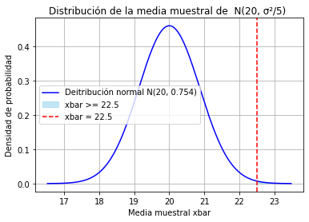

```python
import scipy.stats as stats

# Configuración de los parámetros
mu = 20  # Media de la población
x_bar = 22.5  # Media deseada
n = 5  # Tamaño de la muestra
p_value = 0.002  # Probabilidad deseada

# Calcular el valor correspondiente al puntaje Z
z_value = stats.norm.ppf(1 - p_value)  # 0.002以下の確率に対応するZスコア

# σ
sigma = (x_bar - mu) / (z_value / np.sqrt(n))

print(f"Valor σ: {sigma:.2f}")

x_values = np.linspace(mu - 4*sigma/np.sqrt(n), mu + 4*sigma/np.sqrt(n), 1000)
y_values = stats.norm.pdf(x_values, loc=mu, scale=sigma/np.sqrt(n))

plt.plot(x_values, y_values, label=f'Deitribución normal N({mu}, {sigma**2/n:.3f})', color='blue')
plt.fill_between(x_values, y_values, where=(x_values >= x_bar), color='skyblue', alpha=0.5, label='xbar >= 22.5')
plt.axvline(x=x_bar, color='red', linestyle='--', label='xbar = 22.5')
plt.title('Distribución de la media muestral de  N(20, σ²/5) ')
plt.xlabel('Media muestral xbar')
plt.ylabel('Densidad de probabilidad')
plt.legend()
plt.grid(True)
plt.show()
```

### 2. Distribución de la media muestral $ \bar{x} $ (distribución t) (**$ \sigma $ desconocido**)

サンプルの平均 $ \bar{x} $の分布（ｔ分布）（σ未知）

Si $ \bar{x} $ es la media de una muestra de tamaño n extraída aleatoriamente de una población normal $ N(\mu, \sigma^2) $, y V es la varianza, entonces

$ t = \frac{\bar{x} - \mu }{\sqrt{V/n}}$

sigue una **distribución $ t $** con $ \phi = n-1$ grados de libertad.

[Audio_10](https://drive.google.com/file/d/1xuAHUucG05ieM1pEV77HvpBGrL6l5_G2/view?usp=drive_link)

La distribución $ t $ es simétrica alrededor de cero y su forma está definida por los grados de libertad ($ \phi $), La Figura 3.9 muestra las diferencias en la distribución según los grados de libertad.

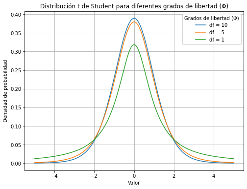

```python
import scipy.stats as stats

# Φ = [10, 5, 1]
df_values = [10, 5, 1]

x = np.linspace(-5, 5, 1000)

plt.figure(figsize=(8, 6))


for df in df_values:
    y = stats.t.pdf(x, df)
    plt.plot(x, y, label=f'df = {df}')

plt.title('Distribución t de Student para diferentes grados de libertad (Φ)')
plt.xlabel('Valor')
plt.ylabel('Densidad de probabilidad')
plt.legend(title='Grados de libertad (Φ)')
plt.grid(True)
plt.show()
```

## 3.8

ｔ分布について次の値を求めよ。

Encuentra a los siguientes valores para la distribución t

1. $ \phi = 8, P = 0.05 $, -> $ t(8: 0.05) $ =
2. $ \phi = 20, P = 0.01 $, -> $ t(20: 0.01) $ =
3. $ \phi = \infty, P = 0.20 $, -> $ t(\infty: 0.20) $ =

```python
import scipy.stats as stats

# Encontrar el valor crítico de la distribución t usando una función:
def t_critical_value(df, p):
    return stats.t.ppf(1 - p/2, df)

# ϕ=8, P=0.05
t_8_0_05 = t_critical_value(8, 0.05)
print(f"t(8:0.05) = {t_8_0_05:.3f}")

# ϕ=20, P=0.01
t_20_0_01 = t_critical_value(20, 0.01)
print(f"t(20:0.01) = {t_20_0_01:.3f}")

# ϕ=∞, P=0.20
t_inf_0_20 = t_critical_value(float('inf'), 0.20)
print(f"t(∞:0.20) = {t_inf_0_20:.3f}")
```

```
t(8:0.05) = 2.306
t(20:0.01) = 2.845
t(∞:0.20) = 1.282
```

### 3. Distribución de la suma de los cuadrados (**distribución chi-cuadrado**)

平方和の分布（χ二乗分布）

La suma de cuadrados $ S = \sum(x_i - \bar{x})^2 $ es un estadístico que representa la variabilidad de la muestra. La distribución de esta S aumenta a medida que lo hace el tamaño de la muestra y la varianza poblacional ($ \sigma^2 $).

Cuando se extrae aleatoriamente una muestra de tamaño $ n $ de una población normal $ N(\mu, \sigma^2) $, la suma de los cuadrados S, entonces

$ \chi^2 = \frac{S}{\sigma^2} $

sigue una distribución chi/cuadrado con grados de libertad $ \phi = n -1 $

El promedio y varianza de la distribución chi-cuadrado son las siguientes:

$ E(\chi^2) = n -1 $

$ V(\chi^2) = 2(n-1) $

$ E(\frac{S}{\sigma^2}) = n-1 => E(\frac{S}{n-1}) = \sigma^2 $

$ V = \frac{S}{n-1} $ => $ E(V) = \sigma^2 $

[Audio_11](https://drive.google.com/file/d/13WoY5BkjflYkEZZGyZaYgphxDGMYcQq6/view?usp=drive_link)

La distribución chi-cuadrado ($ \chi^2 $) se define por sus grados de libertad ($ \phi $). Las diferencias causadas por los grados de libertad ($ \phi $) se muestran en la Figura 3.11.

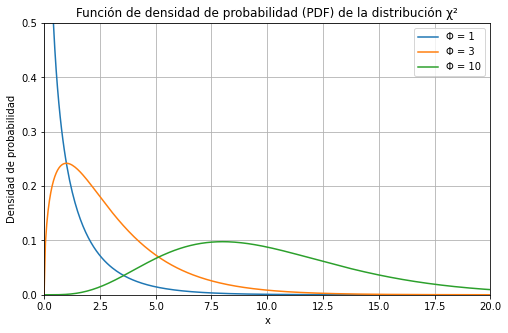

```python
from scipy.stats import chi2

x = np.linspace(0, 30, 500)

#
dfs = [1, 3, 10]

plt.figure(figsize=(8, 5))
for df in dfs:
    plt.plot(x, chi2.pdf(x, df), label=f'Φ = {df}')

plt.title('Función de densidad de probabilidad (PDF) de la distribución χ²')
plt.xlabel('x')
plt.ylabel('Densidad de probabilidad')
plt.xlim(0,20)
plt.ylim(0,0.5)
plt.legend()
plt.grid(True)

plt.show()
```

## 3.9

$ \chi^2 $ 分布について次の値を求めよ。

Encuentra a los siguientes valores para la distribución $ \chi^2 $

1. $ \phi = 8, P = 0.05 $, -> $ \chi^2 (8: 0.05) $ =
2. $ \phi = 8, P = 0.95 $, -> $ \chi^2(8: 0.95) $ =
3. $ \phi = 40, P = 0.95 $, -> $ \chi^2(40: 0.95) $ =

```python
from scipy.stats import chi2

# χ²分布の臨界値を求める関数
def chi2_critical_value(df, p):
    return chi2.ppf(1-p, df)

# ϕ = 8, P = 0.05
chi2_8_0_05 = chi2_critical_value(8, 0.05)
print(f"χ²(8:0.05) = {chi2_8_0_05:.2f}")

# ϕ = 8, P = 0.95
chi2_8_0_95 = chi2_critical_value(8, 0.95)
print(f"χ²(8:0.95) = {chi2_8_0_95:.2f}")

# ϕ = 40, P = 0.95
chi2_40_0_95 = chi2_critical_value(40, 0.95)
print(f"χ²(40:0.95) = {chi2_40_0_95:.1f}")
```

```
χ²(8:0.05) = 15.51
χ²(8:0.95) = 2.73
χ²(40:0.95) = 26.5
```

### 4. Distribución del cociente de varianzas (**distribución F**)

分散の比の分布（F分布）

Si tomamos muestras aleatorias de tamaños n1 y n2 de poblaciones normales $ N(\mu_1, \sigma_1^2) $ y $ N(\mu_2, \sigma_2^2) $ respectivamente, y sus sumas de cuadrados son S1 y S2, entonces $ \chi_1^2 = S_1 / \sigma_1^2 $ y $ \chi_2^2 = S_2 / \sigma_2^2 $ siguen independientemente distribuciones chi-cuadrado con $ \phi_1 = n_1 -1 $ y $ \phi_2 = n_2 -1 $ grados de libertad, respectivamente.

Sin embargo. la razón de $ \chi_1 $ y $ \chi_2 $ divididas por sus respectivos de libertad resulta en una distribución F:

$ F = \frac{V_1/\sigma_1^2}{V_2/\sigma_2^2} $

Si se extraen aleatoriamente muestras de tamaño $ n_1 $ y $ n_2 $ de dos poblaciones normales $ N(\mu_1, \sigma_1^2) $ y $ N(\mu_2, \sigma_2^2) $, y se calculan $ V_1 $ y $ V_2 $, entonces

$ F = \frac{V_1/\sigma_1^2}{V_2 / \sigma_2} $

sigue una distribución F con grados de libertad $ \phi_1 = n_1 -1 $ y $ \phi_2 = n_2 -1 $.

[Audio_12](https://drive.google.com/file/d/13xYnr_c5kzC3XfkSFdbI15XDBzeirocY/view?usp=drive_link)

Esta distribución F está determinada por los grados de libertad del numerador y los grados de libertad del denominador. La Figura 3.13 muestra las diferencias en la distribución según los grados de libertad.

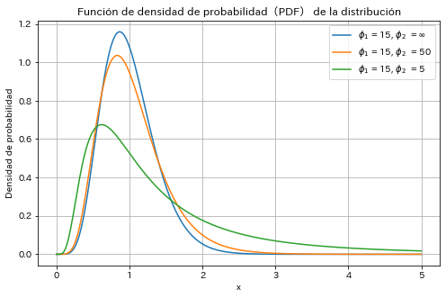

```python
from scipy.stats import f
import japanize_matplotlib

x = np.linspace(0, 5, 500)

# Par de grados de libertad
dof_pairs = [
    (15, np.inf),  # ϕ2 = ∞ se aproxima con un valor grande
    (15, 50),
    (15, 5)
]

plt.figure(figsize=(8, 5))
for df1, df2 in dof_pairs:
    label = r"$ \phi_1 $ " + f"= {df1}," + r" $ \phi_2 $ " + f" = {'∞' if df2 == np.inf else df2}"
    if df2 == np.inf:
        plt.plot(x, f.pdf(x, df1, 1000000), label=label)
    else:
      plt.plot(x, f.pdf(x, df1, df2), label=label)

plt.title('Función de densidad de probabilidad（PDF） de la distribución')
plt.xlabel('x')
plt.ylabel('Densidad de probabilidad')
plt.legend()
plt.grid(True)

plt.show()
```

## 3.10

F 分布について次の値を求めよ。

Encuentra a los siguientes valores para la distribución F

1. $ \phi_1 = 8, \phi_2 = 7, P = 0.05 $, -> $ F (8, 7: 0.05) $ =
2. $ \phi_1 = 1, \phi_2=\infty, P = 0.01 $, -> $ F(1,∞: 0.01) $ =
3. $ \phi_1 = 6, \phi_2=10, P = 0.95 $, -> $ F(6,10: 0.95) $ =

```python
from scipy.stats import f

# F分布の臨界値を求める関数
def f_critical_value(df1, df2, p):
    return f.ppf(1-p, df1, df2)

# ϕ1=8, ϕ2=7, P=0.05
f_8_7_0_05 = f_critical_value(8, 7, 0.05)
print(f"F(8, 7: 0.05) = {f_8_7_0_05:.2f}")

# ϕ1=1, ϕ2=∞, P=0.01
f_1_inf_0_01 = f_critical_value(1, 1000000, 0.01)
print(f"F(1, ∞: 0.01) = {f_1_inf_0_01:.2f}")

# ϕ1=6, ϕ2=10, P=0.95
f_6_10_0_95 = f_critical_value(6, 10, 0.95)
print(f"F(6, 10: 0.95) = {f_6_10_0_95:.3f}")
```

```
F(8, 7: 0.05) = 3.73
F(1, ∞: 0.01) = 6.63
F(6, 10: 0.95) = 0.246
```

大数の法則と中心極限定理

Cuando se toma una muestra $ X = (X_1, X_2,...,X_n) $ de tamaño $ n $ de una población con media poblacional $ E(\bar{X}) = \mu $ y varianza poblacional $ V(\bar{X}) = \sigma^2 $ (no necesariamente una distribución normal) donde los elementos de la muestra son mutuamente independientes, el valor esperado y la varianza de la media muestral $ \bar{X} $ son

- $ E(\bar{X}) = \mu $ y $ V(\bar{X}) = \frac{1}{n} \sigma^2 $.

Por lo tanto, a medida que $ n $ aumenta, $ V(\bar{X}) $disminuye progresivamente.

Cuando n se hace infinitamente grande, la variabilidad de $ \bar{x} $ se hace infinitamente pequeña, esto se llama la **Ley de los Grandes Números**.

Consideramos también la toma de una muestra aleatoria de un proceso con una proporción de no conformidades P. Si la i-ésima muestra es un artículo no conforme, el valor de la vaiable aleatoria $ X_i $ es 1, y si es un artículo conforme, $ X_i = 0 $. La suma de $ X_i $ hasta la n-ésima muestra, $ r = \sum X_i $ representa el número de artículos no conformes en $ n $ unidades. $ P_n = \sum X_i/n $ representa la proporción de artículos no conformes en la muestra. $ p_n $ es la media muestral $ \bar{X} $ de las $ X_i $.

- $ E(p_n) = P, $ y $ V(P_n) = P(1-P) / n $ Se puede aplicar la ley de los grandes números a $ p_n $, y se puede decir que a medida que n tiene a infinito, el valor esperado de la distribución de $ p_n $ se acerca cada vez más a P.

### 2. Teorema Central del Límite

**El Teorema Central del Límite** que la suma de variables aleatorias que siguen cualquier distribución puede aproximarse a una distribución normal.

El Teorema del Límite Central demuestra que, incluso si la distribución de la población original no es normal, la distribución de probabilidad de la media muestral $ \bar{X} $ puede aproximarse a una distribución normal. Esto también se cumple para distribuciones discretas como la distribución binomial y la distribución de Poisson. Es la base para utilizar la aproximación normal en el análisis estadístico de estas distribuciones en pruebas de hipótesis y estimaciones.

[Audio_13](https://drive.google.com/file/d/1YbbnLV-JdCne-uj9KADJxmTTsz82CTne/view?usp=drive_link)

## Por favor, responda a las preguntas del examen de práctica a través del siguiente enlace.

[Simulacro de examen](https://forms.gle/5eTDxEe7vE48ka9h7)

## 10.1

表１０．１に示すようなA、B２種類のくじがある。 下記を求めよ。

1. AとBの賞金の期待値
2. AとBの分散

Se tienen dos tipos de lotería, A y B, como se muestra en la Tabla 10.1. Calcule lo siguiente:

1. El valor esperado de los premios para A y B.
2. La varianza de los premios para A y B.

```python
# くじAのデータ
prizes_A = [100, 10, 5, 0]  # 賞金（0は外れを意味する）
probabilities_A = [0.001, 0.020, 0.040, 0.939]  # 確率（外れの確率は1から全ての当たりの確率を引いたもの）

# くじBのデータ
prizes_B = [20, 5, 1, 0]  # 賞金（0は外れを意味する）
probabilities_B = [0.01, 0.04, 0.10, 0.85]  # 確率（外れの確率は1から全ての当たりの確率を引いたもの）

df1 = pd.DataFrame({'Probability': probabilities_A,'Prize': prizes_A}).T
df2 = pd.DataFrame({'Probability': probabilities_B, 'Prize': prizes_B}).T

df = pd.concat([df1, df2], ignore_index=True)

df.index = ['A_Probabilidad', 'A_Premio', 'B_Probabilidad', 'B_Premio']
df.columns = ['Primer','Segundo','Tercer','Pérdida']

df
```

|  | Primer | Segundo | Tercer | Pérdida |
| --- | --- | --- | --- | --- |
| A_Probabilidad | 0.001 | 0.02 | 0.04 | 0.939 |
| A_Premio | 100.000 | 10.00 | 5.00 | 0.000 |
| B_Probabilidad | 0.010 | 0.04 | 0.10 | 0.850 |
| B_Premio | 20.000 | 5.00 | 1.00 | 0.000 |

```python
def calculate_expected_value_and_variance(prizes, probabilities):
    # 期待値を計算
    expected_value = sum(p * x for p, x in zip(probabilities, prizes))

    # 分散を計算
    variance = sum(p * (x - expected_value) ** 2 for p, x in zip(probabilities, prizes))

    return expected_value, variance

# くじAの期待値と分散を計算
expected_value_A, variance_A = calculate_expected_value_and_variance(prizes_A, probabilities_A)
print(f"El valor esperado de la lotería A: {expected_value_A}")
print(f"La varianza de la lotería A: {variance_A}\n")

# くじBの期待値と分散を計算
expected_value_B, variance_B = calculate_expected_value_and_variance(prizes_B, probabilities_B)
print(f"El valor esperado de la lotería B: {expected_value_B}")
print(f"La varianza de la lotería B: {variance_B:.2f}")
```

```
El valor esperado de la lotería A: 0.5
La varianza de la lotería A: 12.75

El valor esperado de la lotería B: 0.5
La varianza de la lotería B: 4.85
```

## 10.3

Dibujo de la distribución normal

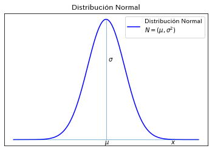

```python
# 標準正規分布の確率密度関数を定義
def standard_normal_distribution(x):
    return (1/np.sqrt(2*np.pi)) * np.exp(-0.5*x**2)

# 描画する範囲を設定
x_values = np.linspace(-5, 5, 1000)
y_values = standard_normal_distribution(x_values)

# グラフを描画
tex1 = "Distribución Normal\n" + r'$N=(\mu, \sigma^2)$'
plt.plot(x_values, y_values, label=tex1, color='blue')
plt.vlines(0,0,y_values.max(), linewidth=0.5)
plt.hlines(0,-5,5,linewidth=0.5)
plt.title('Distribución Normal')

ax = plt.gca()
ax.axes.xaxis.set_visible(False)
ax.axes.yaxis.set_visible(False)

ax.text(0.1, 0.26, r"$\sigma$")
ax.text(-0.1, -0.015, r"$\mu$")
ax.text(3.5, -0.015, r"$x$")

plt.legend()

plt.savefig("Graph2/DistribuciónNormal2.png", format="png", dpi=300)
```

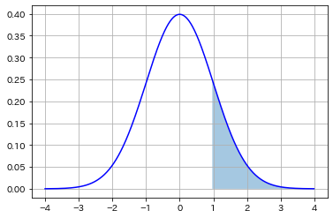

```python
from scipy.stats import norm


# 平均と標準偏差の設定
mean_weight = 0
std_dev_weight = 1

#図を描画する範囲を指定
start = mean_weight - std_dev_weight * 4 #xの左側 (μ-4σ)
end = mean_weight + std_dev_weight * 4 #xの右側 (μ+4σ)

x =np.arange(start,end, 0.01) #xの値を生成
# 確率密度関数を生成
y1 = norm.pdf(x, loc=mean_weight, scale=std_dev_weight)
y2 = 0

x2 = np.linspace(1,2,100)
y3 = norm.pdf(x2, loc=mean_weight, scale=std_dev_weight)
y4 = 0

plt.plot(x, y1, c="b") #正規分布を描画

plt.fill_between(x, y1, y2, where=(x>0.96), alpha=0.4)
# plt.fill_between(x2, y3, y4, alpha=0.4)
plt.grid()

plt.savefig("Graph2/DistribuciónNorma.png", format="png", dpi=300)
```

## 10.3-3

Creación de la tabla de la distribución normal estándar

```python
from scipy.stats import norm

prob_values = []

# 標準正規分布表の作成
for i in np.arange(0, 3.1, 0.01):
      prob_values.append(1- norm.cdf(i))

df = pd.DataFrame(np.array(prob_values).reshape(31,10))
df.index = np.arange(0.0, 3.1, 0.1)
df.to_excel('Data2/TablaDistribucionNormal.xlsx')
df
```

|  | 0 | 1 | 2 | 3 | 4 | 5 | 6 | 7 | 8 | 9 |
| --- | --- | --- | --- | --- | --- | --- | --- | --- | --- | --- |
| 0.0 | 0.500000 | 0.496011 | 0.492022 | 0.488034 | 0.484047 | 0.480061 | 0.476078 | 0.472097 | 0.468119 | 0.464144 |
| 0.1 | 0.460172 | 0.456205 | 0.452242 | 0.448283 | 0.444330 | 0.440382 | 0.436441 | 0.432505 | 0.428576 | 0.424655 |
| 0.2 | 0.420740 | 0.416834 | 0.412936 | 0.409046 | 0.405165 | 0.401294 | 0.397432 | 0.393580 | 0.389739 | 0.385908 |
| 0.3 | 0.382089 | 0.378280 | 0.374484 | 0.370700 | 0.366928 | 0.363169 | 0.359424 | 0.355691 | 0.351973 | 0.348268 |
| 0.4 | 0.344578 | 0.340903 | 0.337243 | 0.333598 | 0.329969 | 0.326355 | 0.322758 | 0.319178 | 0.315614 | 0.312067 |
| 0.5 | 0.308538 | 0.305026 | 0.301532 | 0.298056 | 0.294599 | 0.291160 | 0.287740 | 0.284339 | 0.280957 | 0.277595 |
| 0.6 | 0.274253 | 0.270931 | 0.267629 | 0.264347 | 0.261086 | 0.257846 | 0.254627 | 0.251429 | 0.248252 | 0.245097 |
| 0.7 | 0.241964 | 0.238852 | 0.235762 | 0.232695 | 0.229650 | 0.226627 | 0.223627 | 0.220650 | 0.217695 | 0.214764 |
| 0.8 | 0.211855 | 0.208970 | 0.206108 | 0.203269 | 0.200454 | 0.197663 | 0.194895 | 0.192150 | 0.189430 | 0.186733 |
| 0.9 | 0.184060 | 0.181411 | 0.178786 | 0.176186 | 0.173609 | 0.171056 | 0.168528 | 0.166023 | 0.163543 | 0.161087 |
| 1.0 | 0.158655 | 0.156248 | 0.153864 | 0.151505 | 0.149170 | 0.146859 | 0.144572 | 0.142310 | 0.140071 | 0.137857 |
| 1.1 | 0.135666 | 0.133500 | 0.131357 | 0.129238 | 0.127143 | 0.125072 | 0.123024 | 0.121000 | 0.119000 | 0.117023 |
| 1.2 | 0.115070 | 0.113139 | 0.111232 | 0.109349 | 0.107488 | 0.105650 | 0.103835 | 0.102042 | 0.100273 | 0.098525 |
| 1.3 | 0.096800 | 0.095098 | 0.093418 | 0.091759 | 0.090123 | 0.088508 | 0.086915 | 0.085343 | 0.083793 | 0.082264 |
| 1.4 | 0.080757 | 0.079270 | 0.077804 | 0.076359 | 0.074934 | 0.073529 | 0.072145 | 0.070781 | 0.069437 | 0.068112 |
| 1.5 | 0.066807 | 0.065522 | 0.064255 | 0.063008 | 0.061780 | 0.060571 | 0.059380 | 0.058208 | 0.057053 | 0.055917 |
| 1.6 | 0.054799 | 0.053699 | 0.052616 | 0.051551 | 0.050503 | 0.049471 | 0.048457 | 0.047460 | 0.046479 | 0.045514 |
| 1.7 | 0.044565 | 0.043633 | 0.042716 | 0.041815 | 0.040930 | 0.040059 | 0.039204 | 0.038364 | 0.037538 | 0.036727 |
| 1.8 | 0.035930 | 0.035148 | 0.034380 | 0.033625 | 0.032884 | 0.032157 | 0.031443 | 0.030742 | 0.030054 | 0.029379 |
| 1.9 | 0.028717 | 0.028067 | 0.027429 | 0.026803 | 0.026190 | 0.025588 | 0.024998 | 0.024419 | 0.023852 | 0.023295 |
| 2.0 | 0.022750 | 0.022216 | 0.021692 | 0.021178 | 0.020675 | 0.020182 | 0.019699 | 0.019226 | 0.018763 | 0.018309 |
| 2.1 | 0.017864 | 0.017429 | 0.017003 | 0.016586 | 0.016177 | 0.015778 | 0.015386 | 0.015003 | 0.014629 | 0.014262 |
| 2.2 | 0.013903 | 0.013553 | 0.013209 | 0.012874 | 0.012545 | 0.012224 | 0.011911 | 0.011604 | 0.011304 | 0.011011 |
| 2.3 | 0.010724 | 0.010444 | 0.010170 | 0.009903 | 0.009642 | 0.009387 | 0.009137 | 0.008894 | 0.008656 | 0.008424 |
| 2.4 | 0.008198 | 0.007976 | 0.007760 | 0.007549 | 0.007344 | 0.007143 | 0.006947 | 0.006756 | 0.006569 | 0.006387 |
| 2.5 | 0.006210 | 0.006037 | 0.005868 | 0.005703 | 0.005543 | 0.005386 | 0.005234 | 0.005085 | 0.004940 | 0.004799 |
| 2.6 | 0.004661 | 0.004527 | 0.004396 | 0.004269 | 0.004145 | 0.004025 | 0.003907 | 0.003793 | 0.003681 | 0.003573 |
| 2.7 | 0.003467 | 0.003364 | 0.003264 | 0.003167 | 0.003072 | 0.002980 | 0.002890 | 0.002803 | 0.002718 | 0.002635 |
| 2.8 | 0.002555 | 0.002477 | 0.002401 | 0.002327 | 0.002256 | 0.002186 | 0.002118 | 0.002052 | 0.001988 | 0.001926 |
| 2.9 | 0.001866 | 0.001807 | 0.001750 | 0.001695 | 0.001641 | 0.001589 | 0.001538 | 0.001489 | 0.001441 | 0.001395 |
| 3.0 | 0.001350 | 0.001306 | 0.001264 | 0.001223 | 0.001183 | 0.001144 | 0.001107 | 0.001070 | 0.001035 | 0.001001 |

```python
fp = []

for p in np.arange(0,0.01,0.001):
  fp.append(-norm.ppf(p))

for p in np.arange(0,0.5,0.01):
  fp.append(-norm.ppf(p))

len(fp)
df = pd.DataFrame(np.array(fp).reshape(6,10))
ind = ['0.00','0.0','0.1','0.2','0.3','0.4']
df.index = ind
df.to_excel('Data2/TablaDistribucionNormal2.xlsx')
df
```

|  | 0 | 1 | 2 | 3 | 4 | 5 | 6 | 7 | 8 | 9 |
| --- | --- | --- | --- | --- | --- | --- | --- | --- | --- | --- |
| 0.00 | inf | 3.090232 | 2.878162 | 2.747781 | 2.652070 | 2.575829 | 2.512144 | 2.457263 | 2.408916 | 2.365618 |
| 0.0 | inf | 2.326348 | 2.053749 | 1.880794 | 1.750686 | 1.644854 | 1.554774 | 1.475791 | 1.405072 | 1.340755 |
| 0.1 | 1.281552 | 1.226528 | 1.174987 | 1.126391 | 1.080319 | 1.036433 | 0.994458 | 0.954165 | 0.915365 | 0.877896 |
| 0.2 | 0.841621 | 0.806421 | 0.772193 | 0.738847 | 0.706303 | 0.674490 | 0.643345 | 0.612813 | 0.582842 | 0.553385 |
| 0.3 | 0.524401 | 0.495850 | 0.467699 | 0.439913 | 0.412463 | 0.385320 | 0.358459 | 0.331853 | 0.305481 | 0.279319 |
| 0.4 | 0.253347 | 0.227545 | 0.201893 | 0.176374 | 0.150969 | 0.125661 | 0.100434 | 0.075270 | 0.050154 | 0.025069 |

## 10.4-2

Graficación de la distribución de Poisson

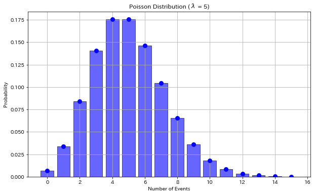

```python
from scipy.stats import poisson

# ポワソン分布のパラメータ
lambda_param = 5  # 平均発生率 (λ)

# x軸の値 (0から15までの整数)
x = np.arange(0, 16)

# ポワソン分布の確率質量関数 (PMF)
pmf = poisson.pmf(x, lambda_param)

# グラフを作成
plt.figure(figsize=(10, 6))
plt.bar(x, pmf, alpha=0.6, color='blue', edgecolor='black')
plt.plot(x, pmf, 'bo', ms=8)  # PMFの点をプロット

# グラフのタイトルとラベル
plt.title('Poisson Distribution (λ = {})'.format(lambda_param))
plt.xlabel('Number of Events')
plt.ylabel('Probability')

# グリッドを追加
plt.grid(True)

# グラフを表示
plt.show()
```

## 10.4-3

Si se extraen 2 muestras de un proceso con una proporción de $ P = 0.10 $, ¿cuál es la probabilidad de que no haya defectuosos en la muestra?

```python
from scipy.stats import binom

def binomial_probability(P, n, x):
    # P: 母不適合率
    # n: サンプルの大きさ
    # x: 不適合品の数

    # 二項分布の確率質量関数を計算
    px = binom.pmf(x, n, P)
    return px

# P = 0.1, n = 2, x = 0
P = 0.10
n = 2
x = 0

probability = binomial_probability(P, n, x)
print(f"Probabilidad P(X = {x}) = {probability:.3f}")
```

```
Probabilidad P(X = 0) = 0.810
```

```
0.810
```

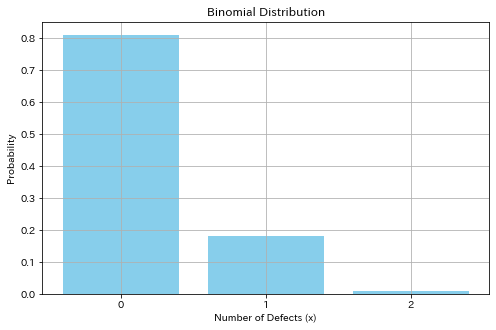

```python
def plot_binomial_distribution(P, n):
    # P: 母不適合率
    # n: サンプルの大きさ

    # x軸の値を設定
    x = np.arange(0, n+1)

    # 二項分布の確率質量関数を計算
    px = binom.pmf(x, n, P)

    #
    px0 = binom.pmf(0, n, P)
    print(f'{px0:.3f}')

    # グラフを描画
    plt.figure(figsize=(8, 5))
    plt.bar(x, px, color='skyblue')
    plt.title('Binomial Distribution')
    plt.xlabel('Number of Defects (x)')
    plt.ylabel('Probability')
    plt.xticks(x)
    plt.grid(True)
    plt.savefig("Graph2/10_3_binomial.png", format="png", dpi=300)

# P = 0.10, n = 2 の場合の二項分布を描画する
P = 0.1
n = 2
plot_binomial_distribution(P, n)
```

## 10.5

ポリ容器に液体製品を自動充填している工程がある。 液体製品の充填量は母平均 $ 1010.0 (ml) $ 母分散 $ 3.0^2 (ml)^2 $ の正規分布に従い、ポリ容器の内容積は母平均 $ 1022.0 (ml) $ 母分散 $ 4.0^2 (ml)^2 $ の正規分布に従っており、互いに独立とする。また、充填前後で液体製品の体積、ポリ容器の内容積は変化しないものとする。 下記を求めよ。

1. 液体充填後ポリ容器の空隙部容積の平均値、母分散
2. ポリ容器から液体があふれる確率
3. 自動充填機を改善し、液体があふれる確率を半分以下にしたい。この時液体充填量の母平均は何％以下にしなければいけないか。

Existe un proceso de llenado automático de un producto líquido en contenedores de polietileno. La cantidad de llenado del producto líquido sigue una distribución normal con una media poblacional de $ 1010.0 (ml) $ y una varianza poblacional de $ 3.0^2 (ml)^2 $. El volumen interno de los contenedores de polietileno sigue una distribución normal con una media poblacional de $ 1022.0 (ml) $ y una varianza poblacional de $ 4.0^2 (ml)^2 $, siendo ambos procesos independientes. Además, se asume que el volumen del producto liquido y el volumen interno de los contenedores de polietileno no cambian antes ni después del llenado.

Calcule lo siguiente:

1. El valor medio y la varianza poblacional del volumen del espacio vacio en los contenedores de polietileno después del llenado del líquido.
2. La probabilidad de que el líquido se derrame del contenedore de polietileno.
3. Se desea mejorar la máquina de llenado automático para que la probabilidad de derrame del líquido sea inferior a la midat. En este caso, ¿a qué porcentaje o menos debe reducirse la media poblacional de la cantidad de llenado del líquido?

```python
# 充填前の液体製品の母平均と母分散
mu_liquid = 1010.0  # ml
var_liquid = 3.0**2

# 充填後のポリ容器の母平均と母分散
mu_container = 1022.0  # ml
var_container = 4.0**2

# 空隙部の母平均の計算
mu_empty = mu_container - mu_liquid

# 空隙部の母分散の計算
var_empty = var_container + var_liquid

# 結果の出力
print(f"La media poblacional del volumen del espacio vacío en los contenedores ")
print(f" de polietileno después del llenado del líquido: {mu_empty} ml\n")
print(f"La varianza poblacional del volumen del espacio vacío en los contenedores")
print(f" de polietileno después del llenado del líquido: {var_empty}")
```

```
La media poblacional del volumen del espacio vacío en los contenedores
 de polietileno después del llenado del líquido: 12.0 ml

La varianza poblacional del volumen del espacio vacío en los contenedores
 de polietileno después del llenado del líquido: 25.0
```

```python
# 充填前の液体製品の母平均と母分散
mu_liquid = 1010.01  # ml
var_liquid = 3.0**2

# 充填後のポリ容器の母平均と母分散
mu_container = 1022.0  # ml
var_container = 4.0**2

# 空隙部の母平均と母分散の計算
mu_empty = mu_container - mu_liquid
var_empty = var_container + var_liquid

# 空隙部が0以下になる確率を求める
# 標準化してから計算する
std_dev_empty = np.sqrt(var_empty)  # 標準偏差の計算

# 標準正規分布での確率を計算する
overflow_prob = stats.norm.cdf(0, loc=mu_empty, scale=std_dev_empty)

# 結果の出力
print(f"La probabilidad de que el líquido se derrame del contenedor de polietileno: {overflow_prob:.4f}")
```

```
La probabilidad de que el líquido se derrame del contenedor de polietileno: 0.0082
```

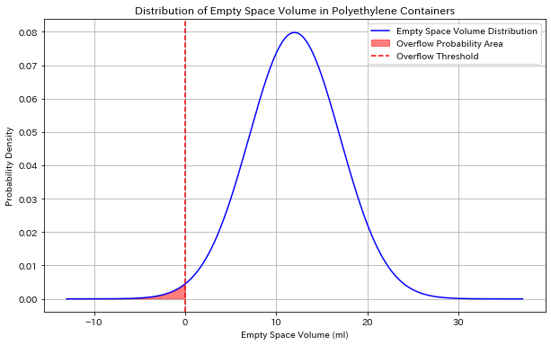

```python
# 充填前の液体製品の母平均と母分散（初期値）
mu_liquid = 1010.0  # ml
var_liquid = 3.0**2

# 充填後のポリ容器の母平均と母分散
mu_container = 1022.0  # ml
var_container = 4.**2

# 空隙部の母平均と母分散の計算
mu_empty = mu_container - mu_liquid
var_empty = var_container + var_liquid
std_dev_empty = np.sqrt(var_empty)

# xの範囲を設定
x = np.linspace(mu_empty - 5*std_dev_empty, mu_empty + 5*std_dev_empty, 1000)

# 正規分布の確率密度関数
pdf = stats.norm.pdf(x, mu_empty, std_dev_empty)

# グラフを描画
plt.figure(figsize=(10, 6))
plt.plot(x, pdf, label='Empty Space Volume Distribution', color='blue')
plt.fill_between(x, pdf, where=(x <= 0), color='red', alpha=0.5, label='Overflow Probability Area')
plt.axvline(0, color='red', linestyle='--', label='Overflow Threshold')
plt.title('Distribution of Empty Space Volume in Polyethylene Containers')
plt.xlabel('Empty Space Volume (ml)')
plt.ylabel('Probability Density')
plt.legend()
plt.grid(True)
plt.savefig("Graph2/10_5_2.png", format="png", dpi=300)
```

```python
# 充填前の液体製品の母平均と母分散（初期値）
mu_liquid = 1010.  # ml
var_liquid = 3.0**2

# 充填後のポリ容器の母平均と母分散
mu_container = 1022.0  # ml
var_container = 4.0**2

# 空隙部の母平均と母分散の計算
mu_empty = mu_container - mu_liquid
var_empty = var_container + var_liquid
std_dev_empty = np.sqrt(var_empty)

# 現在のあふれる確率と新しいあふれる確率
current_prob = overflow_prob
new_prob = current_prob * 0.5

# 現在のあふれる確率に対応するzスコア
current_z = stats.norm.ppf(1 - current_prob)

# 新しいあふれる確率に対応するzスコア
new_z = stats.norm.ppf(1 - new_prob)

# 新しい標準偏差を計算する
new_std_dev_empty = mu_empty / new_z

# 新しい分散を計算する
new_var_empty = new_std_dev_empty**2

print(f"var_x: {new_std_dev_empty:.3f}")

# 液体製品の新しい母分散を計算する
new_var_liquid = new_var_empty - var_container

# 結果の出力
print(f"La nueva varianza poblacional del producto líquido: {np.sqrt(new_var_liquid):.2f}^2 (ml)^2")
```

```
var_x: 4.542
La nueva varianza poblacional del producto líquido: 2.15^2 (ml)^2
```

## 10.6

機械部品を製造している工程がある。この部品の重要特性の一つは重量であり、母平均 $ 100.000 (g) $、母標準偏差 $ 0.100 (g) $ の正規分布に従っている。

Existe un proceso de fabricación de piezas mecánicas. Una de las caracteristicas importantes de estas piezas el el peso, el cual sigue una distribución normal con una media poblacional de $ 100.000 (g) $ y una desviación estándar poblacional de $ 0.100 (g) $.

1. サンプルをランダムに１個採取した。このサンプルの重量が 99.750 (g) 以下、100.250 (g)以上である確率を求めよ
1. Si se toma una muestra aleatoria de una pieza, calcule la probabilidad de que el peso de esta muestra sea menor o igual a 99.750 (g) o mayor o igual a 100.250 (g).

```
La probabilidad de que el peso sea menor o igual a99.75 (g)
  o mayor o igual a 100.25 (g): 0.01242
```

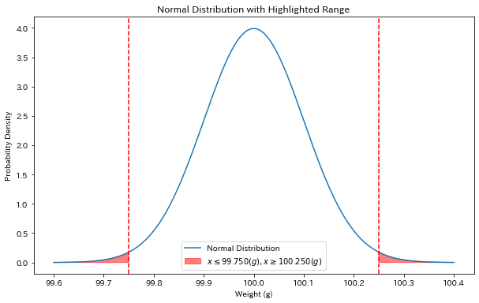

```python
# 正規分布のパラメータ
mean = 100.000  # 母平均
std_dev = 0.100  # 母標準偏差

# 範囲の定義
lower_bound = 99.750
upper_bound = 100.250

# 正規分布のデータポイントを生成
x = np.linspace(mean - 4*std_dev, mean + 4*std_dev, 1000)
y = stats.norm.pdf(x, mean, std_dev)

# 下限以下の確率と上限以上の確率を計算
prob_lower = stats.norm.cdf(lower_bound, mean, std_dev)
prob_upper = 1 - stats.norm.cdf(upper_bound, mean, std_dev)

# 合計確率
total_probability = prob_lower + prob_upper

# 結果の表示
print(f"La probabilidad de que el peso sea menor o igual a{lower_bound} (g) ")
print(f"  o mayor o igual a {upper_bound} (g): {total_probability:.5f}")

# グラフの作成
plt.figure(figsize=(10, 6))
plt.plot(x, y, label='Normal Distribution')
plt.fill_between(x, y, where=(x <= lower_bound) | (x >= upper_bound), color='red', alpha=0.5, label=r'$ x \leq 99.750 (g),  x \geq 100.250 (g) $')
plt.axvline(lower_bound, color='red', linestyle='--')
plt.axvline(upper_bound, color='red', linestyle='--')
plt.title('Normal Distribution with Highlighted Range')
plt.xlabel('Weight (g)')
plt.ylabel('Probability Density')
plt.legend()
```

1. サンプルをランダムに４個採取した。これらのサンプルんの合計が、399.500(g)以下、あるいは400.500(g)以上である確率を求めよ。
1. Se toman cuatro muestras alatorias de piezas. Calcule la probabilidad de que la suma de los pesos de estas muestras sea menor o equal a 399.500 (g) o mayor o igual a 400.500 (g).

```
La probabilidad de que el peso total de estas muestras sea menor o igual a 399.5 (g)
  o mayor o igual a 400.5 (g): 0.01242
```

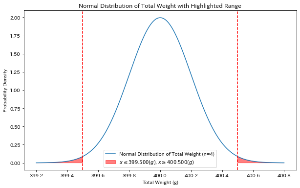

```python
# 正規分布のパラメータ
mean_single = 100.000  # 母平均
std_dev_single = 0.100  # 母標準偏差

# サンプル数
n_samples = 4

# サンプル合計の分布パラメータ
mean_total = n_samples * mean_single
std_dev_total = np.sqrt(n_samples) * std_dev_single

# 範囲の定義
lower_bound_total = 399.500
upper_bound_total = 400.500

# 正規分布のデータポイントを生成
x = np.linspace(mean_total - 4*std_dev_total, mean_total + 4*std_dev_total, 1000)
y = stats.norm.pdf(x, mean_total, std_dev_total)

# 下限以下と上限以上の確率を計算
prob_lower_total = stats.norm.cdf(lower_bound_total, mean_total, std_dev_total)
prob_upper_total = 1 - stats.norm.cdf(upper_bound_total, mean_total, std_dev_total)

# 合計確率
total_probability = prob_lower_total + prob_upper_total

# グラフの作成
plt.figure(figsize=(10, 6))
plt.plot(x, y, label='Normal Distribution of Total Weight (n=4)')
plt.fill_between(x, y, where=(x <= lower_bound_total) | (x >= upper_bound_total), color='red', alpha=0.5, label=r'$ x \leq 399.500 (g), x \geq 400.500 (g) $')
plt.axvline(lower_bound_total, color='red', linestyle='--')
plt.axvline(upper_bound_total, color='red', linestyle='--')
plt.title('Normal Distribution of Total Weight with Highlighted Range')
plt.xlabel('Total Weight (g)')
plt.ylabel('Probability Density')
plt.legend()

# 結果の表示
print(f"La probabilidad de que el peso total de estas muestras sea menor o igual a {lower_bound_total} (g) ")
print(f"  o mayor o igual a {upper_bound_total} (g): {total_probability:.5f}")
# グラフを表示
plt.show()
```

1. サンプルをランダムに４個採取した。これらのサンプルの平均重量が 99.875 (g)以下、あるいは、100.125 (g) 以上である確率をもとめよ。
1. Se toman cuatro muestras aleatorias de piezas. Calcule la probabilidad de que el peso promedio de estas muestra sea menor o igual a 99.875 (g) o mayor o igual a 100.125 (g).

[output not shown]

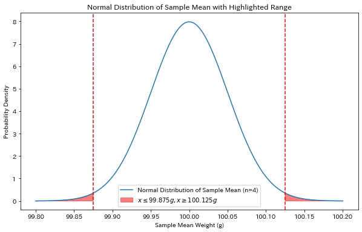

```python
# 正規分布のパラメータ
mean_single = 100.000  # 母平均
std_dev_single = 0.100  # 母標準偏差

# サンプル数
n_samples = 4

# サンプル平均の分布パラメータ
mean_average = mean_single
std_dev_average = std_dev_single / np.sqrt(n_samples)

# 範囲の定義
lower_bound_average = 99.875
upper_bound_average = 100.125

# 正規分布のデータポイントを生成
x = np.linspace(mean_average - 4*std_dev_average, mean_average + 4*std_dev_average, 1000)
y = stats.norm.pdf(x, mean_average, std_dev_average)

# 下限以下と上限以上の確率を計算
prob_lower_average = stats.norm.cdf(lower_bound_average, mean_average, std_dev_average)
prob_upper_average = 1 - stats.norm.cdf(upper_bound_average, mean_average, std_dev_average)

# 合計確率
total_probability = prob_lower_average + prob_upper_average

# グラフの作成
plt.figure(figsize=(10, 6))
plt.plot(x, y, label='Normal Distribution of Sample Mean (n=4)')
plt.fill_between(x, y, where=(x <= lower_bound_average) | (x >= upper_bound_average), color='red', alpha=0.5, label=r'$ x \leq 99.875g, x \geq 100.125g $')
plt.axvline(lower_bound_average, color='red', linestyle='--')
plt.axvline(upper_bound_average, color='red', linestyle='--')
plt.title('Normal Distribution of Sample Mean with Highlighted Range')
plt.xlabel('Sample Mean Weight (g)')
plt.ylabel('Probability Density')
plt.legend()

# 結果の表示
print(f"La probabilidad de que el peso promedio de estas muestras sea menor o igual a{lower_bound_total} (g) ")
print(f"  o mayor o igual a {upper_bound_total} (g): {total_probability:.5f}")

# グラフを表示
plt.show()
```

## 10.7

Q社では焼き菓子を製造している。焼きあがったお菓子はランダムに１０個をひと箱に詰めて箱詰めお菓子として出荷する。 お菓子の重量は平均50.00(g)、母標準偏差1.50(g)の正規分布に従い、また、箱の重量は母平均 5.00(g)、母標準偏差 0.50(g)の正規分布に従っている。

La empresa Q se dedica a la fabricación de galletas horneadas. Las galletas horneadas se empaquetan aleatoriamente en cajas de diez unidades para su envio como paquetes de galletas. El peso de las galletas sigue una distribución normal con una media de 50.00(g) y una desviación estándar poblacional de 1.50(g). El peso de las cajas cigue una distribución normal con una media poblacional de 5.00(g) y una desviacion estándar poblacional de 0.50 (g).

1. １０個入り箱詰めお菓子の総重量の母平均、母標準偏差を求めよ。
1. Calcule la media poblacional y la desviación estándar poblacional del peso total de un paquetes de 10 galletas.

```python
# 現在の設定
mean_candy_initial = 50.00        # お菓子の平均重量（g）
std_dev_candy = 1.50              # お菓子の標準偏差（g）
mean_box = 5.00                   # 箱の平均重量（g）
std_dev_box = 0.50                # 箱の標準偏差（g）
n_candies = 10                    # お菓子の個数（1箱あたり）


# 総重量の母平均の計算
mean_total_weight = n_candies * mean_candy_initial + mean_box

# 総重量の母標準偏差の計算
std_dev_total_weight = np.sqrt(n_candies * std_dev_candy**2 + std_dev_box**2)

# 結果の表示
print(f"La media poblacional del peso total de un paquete de 10 galletas: {mean_total_weight:.2f} g")
print(f"La desviación estándar poblacional del peso total de un paquete de 10 galletas: {std_dev_total_weight:.2f} g")
```

```
La media poblacional del peso total de un paquete de 10 galletas: 505.00 g
La desviación estándar poblacional del peso total de un paquete de 10 galletas: 4.77 g
```

1. 総重量が 495.00 (g) 以下の箱は不合格となる。不適合品のでる確率を求めよ。
1. Un paquete con un peso total de 495.00 (g) o menos se considera no conforme. Calcule la probabilidad de que un paquete sea no conforme.

```python
# 総重量の母平均の計算
mean_total_weight = n_candies * mean_candy_initial + mean_box

# 総重量の母標準偏差の計算
std_dev_total_weight = np.sqrt(n_candies * std_dev_candy**2 + std_dev_box**2)

# 不適合となる重量（495g以下）の確率を計算
threshold_weight = 495.0
probability_below_threshold = stats.norm.cdf(threshold_weight, mean_total_weight, std_dev_total_weight)

# 結果の表示
print(f"La probabilidad de que el peso total sea menor o igual a {threshold_weight}g : {probability_below_threshold:.5f}")
```

```
La probabilidad de que el peso total sea menor o igual a 495.0g : 0.01802
```

```python
# 不適合率上限（0.1%）
target_probability = 0.001

# 総重量の標準偏差（お菓子10個＋箱）
std_dev_total_weight = np.sqrt(n_candies * std_dev_candy**2 + std_dev_box**2)

# 標準正規分布における 0.1% 点（下側）
z = stats.norm.ppf(target_probability)  # 例: -3.0902

# 必要な総重量の母平均を逆算（この平均を持っていれば、0.1%しか495g未満にならない）
required_mean_total = threshold_weight - z * std_dev_total_weight

# そこから必要なお菓子の平均を求める
mean_candy_required = (required_mean_total - mean_box) / n_candies

# 出力
print(f"El peso medio poblacional requerido de las galletas.: {mean_candy_required:.2f} g")
```

```
El peso medio poblacional requerido de las galletas.: 50.47 g
```

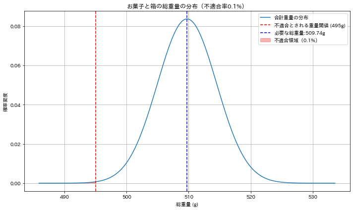

```python
import japanize_matplotlib

# グラフ描画
x = np.linspace(required_mean_total - 5 * std_dev_total_weight,
                required_mean_total + 5 * std_dev_total_weight, 1000)
y = norm.pdf(x, loc=required_mean_total, scale=std_dev_total_weight)

plt.figure(figsize=(10, 6))
plt.plot(x, y, label='合計重量の分布')
plt.axvline(threshold_weight, color='red', linestyle='--', label='不適合とされる重量閾値 (495g)')
plt.axvline(required_mean_total, color='blue', linestyle='--', label=f'必要な総重量:{required_mean_total:.2f}g')
plt.fill_between(x, y, 0, where=(x < threshold_weight), color='red', alpha=0.3, label='不適合領域（0.1%）')
plt.title('お菓子と箱の総重量の分布（不適合率0.1%）')
plt.xlabel('総重量 (g)')
plt.ylabel('確率密度')
plt.legend()
plt.grid(True)
plt.tight_layout()
plt.show()
```

```python
notebook_name = 'QCKentei2-3.ipynb'
notebook_name_html = notebook_name.replace(".ipynb",".html")

!jupyter nbconvert --to html {notebook_name}
```

```
[NbConvertApp] Converting notebook QCKentei2-3.ipynb to html
[NbConvertApp] Writing 1960065 bytes to QCKentei2-3.html
```

```python
from IPython.display import display
from PIL import Image
import gdown
import re

def get_file_id(url,out):
    # 正規表現でファイルIDを抽出
    match = re.search(r'/d/([a-zA-Z0-9_-]+)', url)

    if match:
        file_id = match.group(1)
        print("ファイルID:", file_id)
    else:
        print("ファイルIDが見つかりませんでした。")

    url = f"https://drive.google.com/uc?id={file_id}"

    output = out

    gdown.download(url, output, quiet=False)

    img = Image.open(out)
    display(img)
```

```python
url= 'https://drive.google.com/file/d/1qOB04nzA8Xo7XubZN6Rqrk5ETFCT1g4T/view?usp=drive_link'
out = './Graph2/norm3.png'
#get_file_id(url,out)
```